# R Notebook: o-well

Peyton Urquhart [peyton.urquhart]

```
## [1] "Retreived Well Datasets At:"
```

```
## [1] "C:/_git_/peyton.urquhart/datasets/o-well/wells-metals.csv"
```

```
## [1] "C:/_git_/peyton.urquhart/datasets/o-well/wells-chemistry.csv"
```

# Gathering Well Data

Well data is stored in a Comma Separated Values files (.csv), it can then be directly read into a dataframe using the read.csv() function. All necessary data was added to the .csv files prior to reading the data to a dataframe.

# Well Data

owell.metals contains data of dissolved metals detected in water-samples from wells 1-23 in ug/L.

owell.chemistry contains datapoints for physical and chemical paramaters in ground-water samples from wells 1-23 in mg/L.

Additionally, each dataset includes location and altitude (Feet) for the wells, approximate distance from the nearest fault-line (Meters), approximate distance from the saltwater gulf (Meters), and the surrounding geology.

owell.metals and owell.chemistry are placed into a list to be refrenced by wells$saudi$chemistry and wells$saudi$metals

## Mean Water Contents

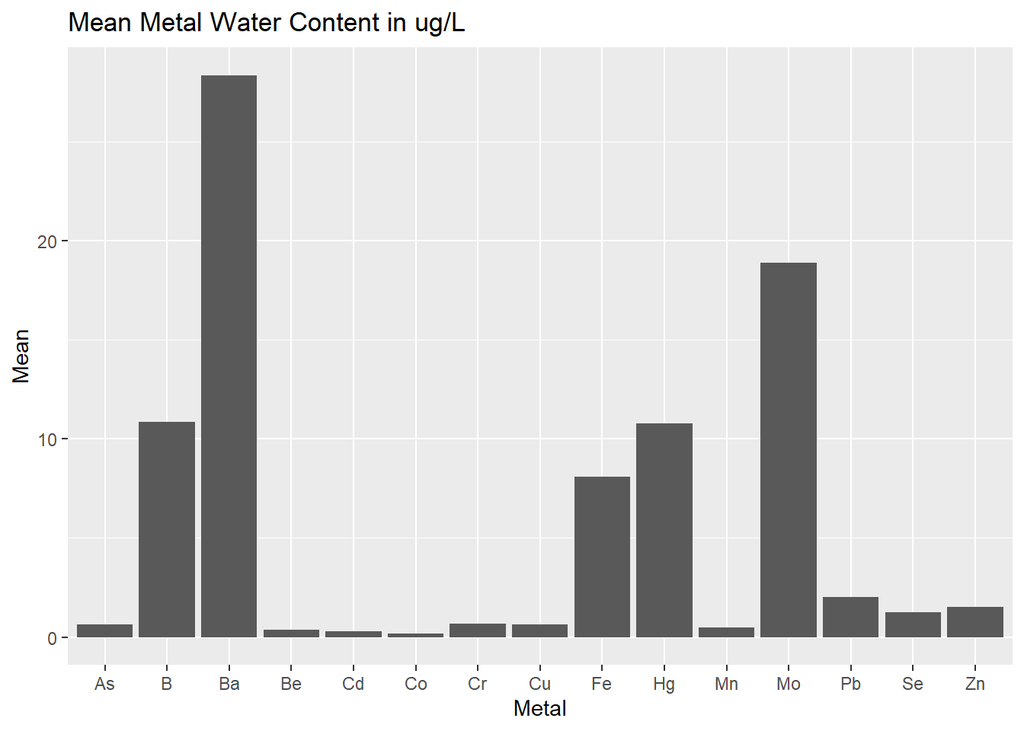

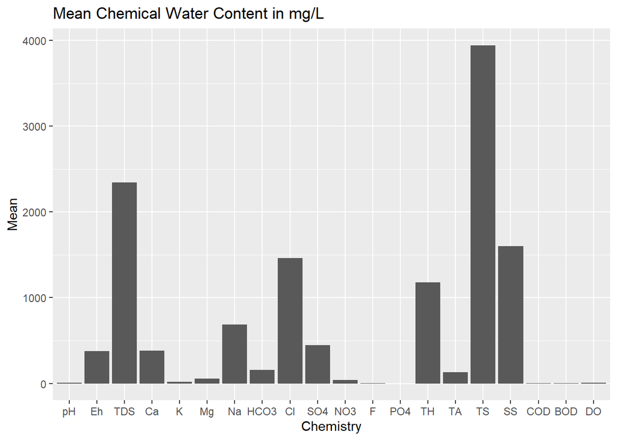

## Coefficients of Variance for Water Contents

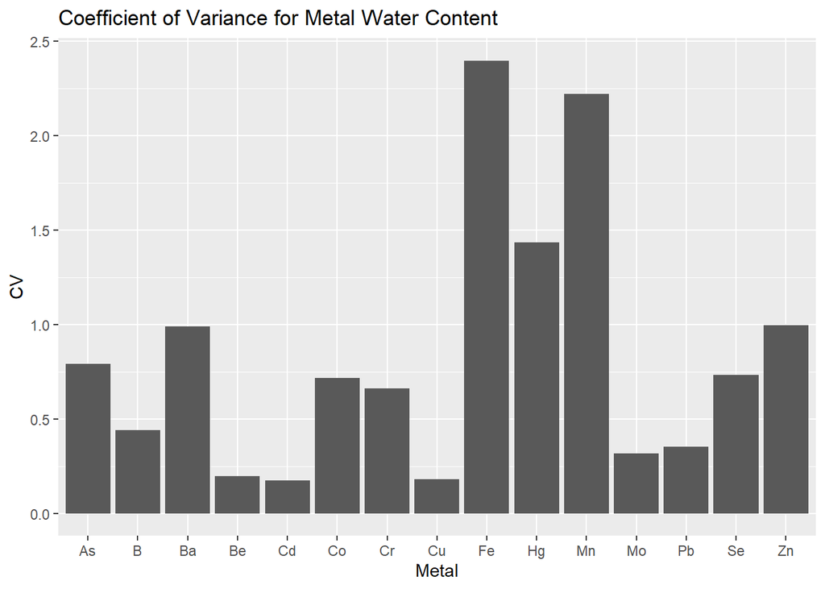

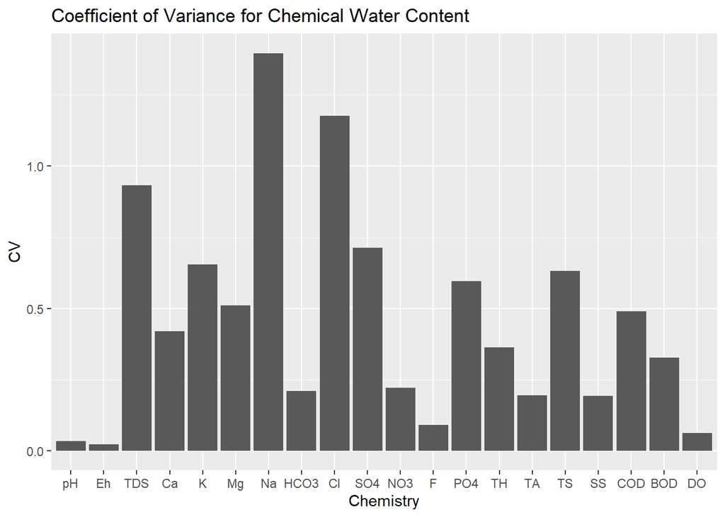

# Mercury Content in Well Water

“The U.S. Environmental Protection Agency (EPA) sets a Maximum Contaminant Level (MCL) for mercury in drinking water of 0.002 mg/L” (https://epi.dph.ncdhhs.gov/).

In other words, It has been determined that a concentration of Hg greater than 2 micrograms per liter (ug/L) is potentially unsafe for drinking.

From the above data, the mean Hg content for wells 1-23 is 10 ug/L (about than 5 times what is considered safe) and the coefficient of variance is high. This indicates that there are outside factors which significantly influence concentration of Hg in the water and may bring it to dangerous levels.

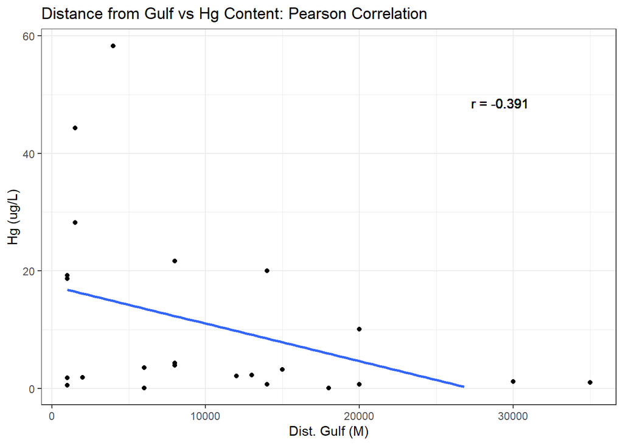

There is a weak correlation between a wells distance from the gulf, and its mercury content. As wells become closer to the gulf, there appears to be a greater probability for very high levels of mercury in a water sample.

This can be further explored by examining mercury content based on a wells sandy/not sandy surrounding geology. Perhaps, water from the gulf seeking into the source for the well becomes more prominent when the type of soil is sandy as opposed to rocky.

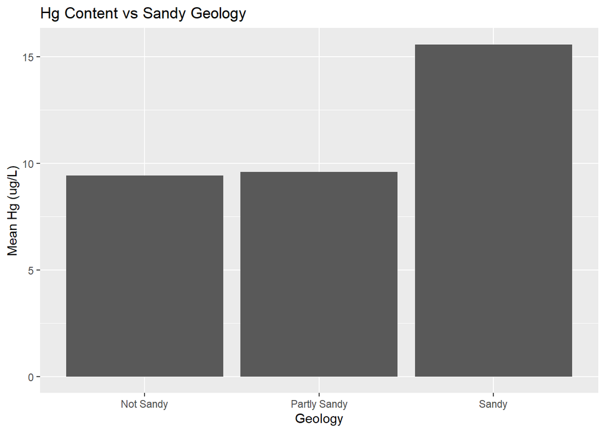

# Sodium Content in Well Water

It is logical to think that when wells are closer to the saltwater gulf, there will be a greater concentration of sodium found. A test for this correlation returns a weak correlation coefficient between these two variables.

Interestingly, a much stronger correlation is found for Na Content vs Distance from Fault-Line. I speculate that this is because wells that are close to a fault are exposed to fresh flowing groundwater which is rapidly replenished, reducing the amount of stagnating saltwater from the gulf.

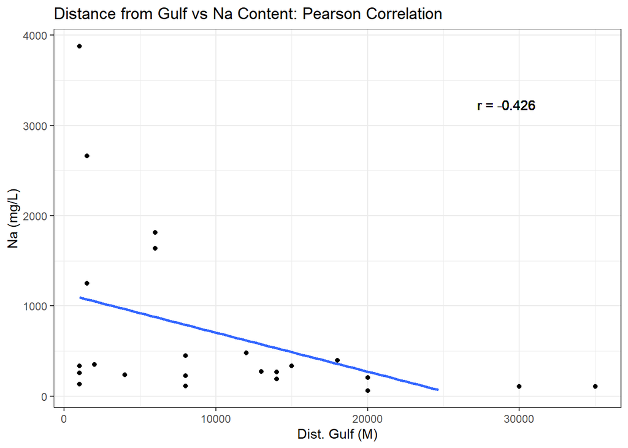

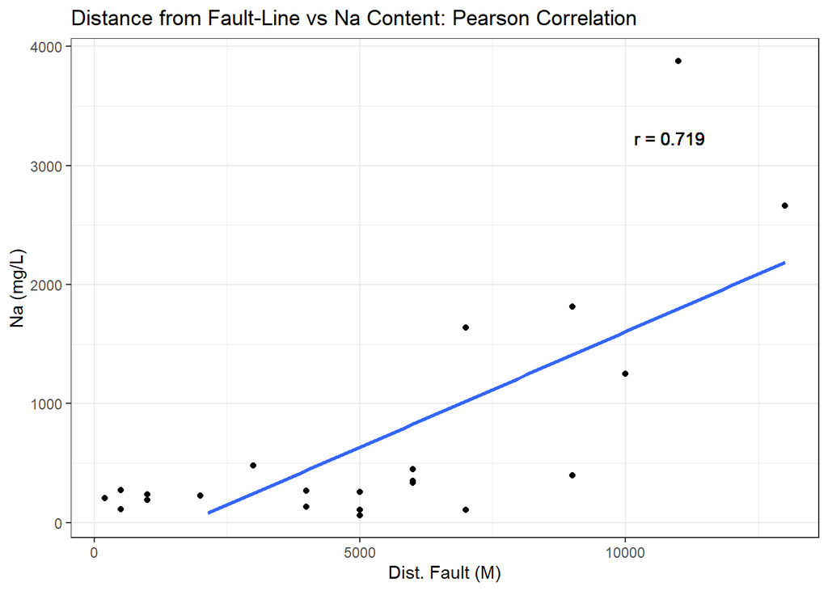

Although drinking saltwater does not put anyone in immediate danger, drinking 1 gallon of water from the most sodium-concentrated well in the data set, would subject a person to about 6 times a healthy daily allowance of sodium.

# Conclusion

The data leads me to believe that there should be an emphasis on placing wells directly on a fault-line. There is also evidence that placing wells very near the saltwater gulf could lead to hazardous metals in the water.